# Meeting 06/07

- Questions

Since now we now the pooled embedding can encode the object information, what's the impact of the input dimension? In another words, what's the impact of tile size on encoding dugong-related information.

```python
df_1024 = pd.read_parquet("/share/home/e2406743/code/Dugongs_IRISA-MARBEC-LIRMM/chapter3/results_classification/in1024_wptrained_UMtest.parquet")
df_2048 = pd.read_parquet("/share/home/e2406743/code/Dugongs_IRISA-MARBEC-LIRMM/chapter3/results_classification/in2048_wptrained_UMtest.parquet")
```

# Methodology

Binary classification of tiles with respect different input dimensions.

Initial Conditions:

- NC dataset has a widthxheight of 2704x1520. So a tile of 2048 is not possible. | EXCLUDED
- WPmix is a reduced dataset with mixed Manual and FLPLAN flights from the subregions: UM, GAM, MANTASANDY, FRIWEN. The size of the images are: (5472,3648) (4096,2160) (3840,2160), (4000,3000).
- UMflplan. Only transects flights. TEST SET. Sizes: (5472,3648) (5280,3956), (4000,3000).

-- WPmix and UMflplan are tiled into 1024x1024 with 224 overlapping AND 2048x2048 with 224 overlapping. From each tile, a forward pass of Dinov3 model is done to retrieve the embeddings.

All classification are based on these embeddings.

TRAIN: Wpmix | TEST: UM_flplan

--

Tiling Process: Giving a stride of size (1024 OR 2048) and 224 overlap, the images are tiled into smaller images. The condition of either presence or absence of dugongs is given by solely if it contains a bbox of dugong or not within the image tile. However, boundaries tile-regions can be tricky, therefore, during the overlap, if the bbox representing the dugong is reduced more than a threshold area ratio (0.45) that bbox is therefore desconsidered. Allowing only bbox with at least 55% percent of area remaining to be considered a positive label.

```
This avoids the tiles of being considered positives and only containing a very small fraction of the dugong. However, on the other hand, it may flag as negative some tiles that may contain a distinct visual feature, for instance, the tail of a dugong.
```

```python
dataset = fo.load_dataset("tiles2048_merged")
```

```python
for sample in dataset.iter_samples(progress=True):
    sample['count_pos_sr'] = str(sample.get_field('type_label'))+'_'+str(sample.get_field('dataset_sr'))
    sample.save()
```

```
 100% |███████████████| 1540/1540 [1.4s elapsed, 0s remaining, 1.1K samples/s]
```

```python
dataset.count_values("dataset_sr")
```

```
{'UM_flplan': 636, 'WPmix': 904}
```

```python
dataset = fo.load_dataset('tiles_merged')
dataset_view = dataset.match(
    (ViewField("dataset_sr").contains_str("WPmix")) |
    (ViewField("dataset_sr").contains_str("UM_flplan"))
)
dataset_view
```

```
Dataset:     tiles_merged
Media type:  image
Num samples: 5395
Sample fields:
    id:               fiftyone.core.fields.ObjectIdField
    filepath:         fiftyone.core.fields.StringField
    tags:             fiftyone.core.fields.ListField(fiftyone.core.fields.StringField)
    metadata:         fiftyone.core.fields.EmbeddedDocumentField(fiftyone.core.metadata.ImageMetadata)
    created_at:       fiftyone.core.fields.DateTimeField
    last_modified_at: fiftyone.core.fields.DateTimeField
    type_label:       fiftyone.core.fields.StringField
    ground_truth:     fiftyone.core.fields.EmbeddedDocumentField(fiftyone.core.labels.Detections)
    region:           fiftyone.core.fields.StringField
    mission_name:     fiftyone.core.fields.StringField
    parent_name:      fiftyone.core.fields.StringField
    gt_field:         fiftyone.core.fields.StringField
    min_area_ratio:   fiftyone.core.fields.FloatField
    n_boxes_in_tile:  fiftyone.core.fields.IntField
    n_boxes_written:  fiftyone.core.fields.IntField
    source_image:     fiftyone.core.fields.StringField
    tile_name:        fiftyone.core.fields.StringField
    x_start:          fiftyone.core.fields.IntField
    y_start:          fiftyone.core.fields.IntField
    dataset_sr:       fiftyone.core.fields.StringField
    umap:             fiftyone.core.fields.ListField(fiftyone.core.fields.FloatField)
    cluster_label:    fiftyone.core.fields.FloatField
    uniqueness_score: fiftyone.core.fields.FloatField
    count_pos_sr:     fiftyone.core.fields.StringField
    subregion:        fiftyone.core.fields.StringField
    source_stem:      fiftyone.core.fields.StringField
View stages:
    1. Match(filter={'$expr': {'$or': [...]}})
```

```python
#  Count how many postive/negative images per dataset source
dataset.count_values("count_pos_sr")
```

[output not shown]

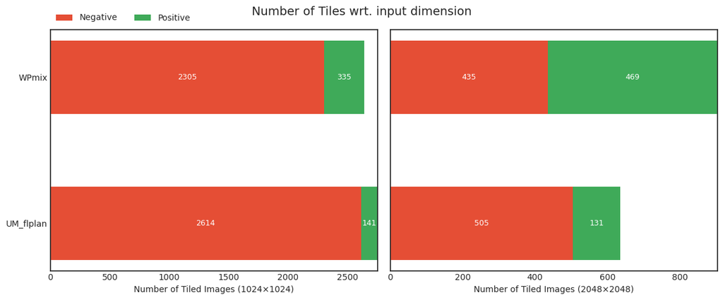

# Results

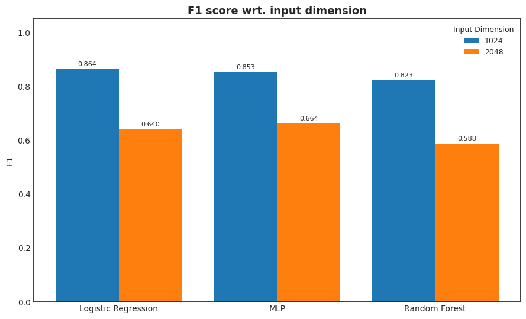

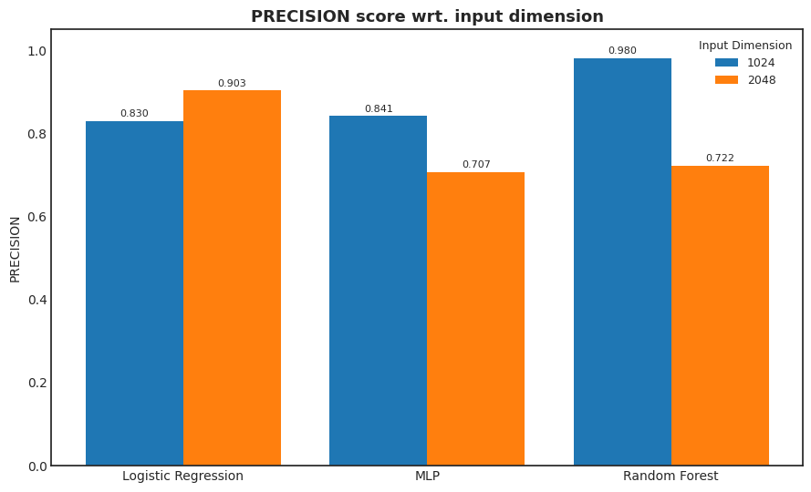

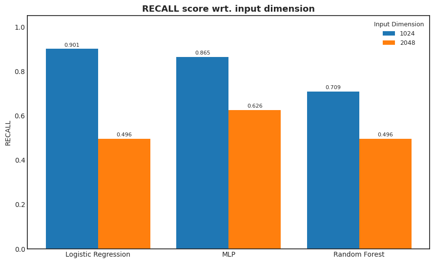

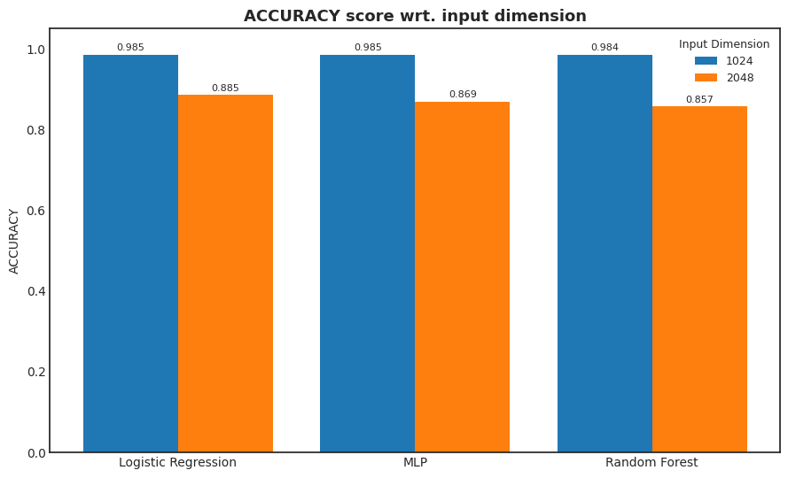

# GIF

```python
df_nc_results = pd.read_parquet("/share/home/e2406743/code/Dugongs_IRISA-MARBEC-LIRMM/chapter3/results_classification/nctrained_UMtest.parquet")
df_wpnoum_results = pd.read_parquet("/share/home/e2406743/code/Dugongs_IRISA-MARBEC-LIRMM/chapter3/results_classification/nctrained_WPmixnoUM_UMtest.parquet")
df_wpmix_results = pd.read_parquet("/share/home/e2406743/code/Dugongs_IRISA-MARBEC-LIRMM/chapter3/results_classification/nctrained_WPmixALL_UMtest.parquet")
```

```python
df_concat = pd.concat([df_nc_results,df_wpnoum_results,df_wpmix_results])
```

```python
# Trained on NC and WP (FRIWEN, UM, GAM, MANTASANDY)
metrics = compute_metric_table(df_wpmix_results)
metrics
```

|  | model | DOMAIN_SHIFT | accuracy | precision | recall | f1 |
| --- | --- | --- | --- | --- | --- | --- |
| 0 | Logistic Regression | NCandWPmixALL | 0.982940 | 0.813333 | 0.865248 | 0.838488 |
| 1 | MLP | NCandWPmixALL | 0.985844 | 0.892308 | 0.822695 | 0.856089 |
| 2 | Random Forest | NCandWPmixALL | 0.986570 | 0.948276 | 0.780142 | 0.856031 |

```python
# Trained only in NC
metrics = compute_metric_table(df_nc_results)
metrics
```

|  | model | DOMAIN_SHIFT | accuracy | precision | recall | f1 |
| --- | --- | --- | --- | --- | --- | --- |
| 0 | Logistic Regression | NCtrained | 0.965517 | 0.610577 | 0.900709 | 0.727794 |
| 1 | MLP | NCtrained | 0.948094 | 0.496241 | 0.936170 | 0.648649 |
| 2 | Random Forest | NCtrained | 0.985844 | 0.864286 | 0.858156 | 0.861210 |

```python
# Trained only in WP(GAM, MANTASANDY, UM, FRIWEN)
metrics = compute_metric_table(df_1024)
metrics["DOMAIN_SHIFT"] = ["onlyWP_noNC" for r in range(len(metrics))]
metrics
```

|  | model | DOMAIN_SHIFT | accuracy | precision | recall | f1 |
| --- | --- | --- | --- | --- | --- | --- |
| 0 | Logistic Regression | onlyWP_noNC | 0.985481 | 0.830065 | 0.900709 | 0.863946 |
| 1 | MLP | onlyWP_noNC | 0.984755 | 0.841379 | 0.865248 | 0.853147 |
| 2 | Random Forest | onlyWP_noNC | 0.984392 | 0.980392 | 0.709220 | 0.823045 |

```python
# Trained in NC and WP (FRIWEN, GAM, MANTASANDY) - NO WP
metrics = compute_metric_table(df_wpnoum_results)
metrics
```

|  | model | DOMAIN_SHIFT | accuracy | precision | recall | f1 |
| --- | --- | --- | --- | --- | --- | --- |
| 0 | Logistic Regression | NCandWPnoUM | 0.978584 | 0.732955 | 0.914894 | 0.813880 |
| 1 | MLP | NCandWPnoUM | 0.966969 | 0.617925 | 0.929078 | 0.742210 |
| 2 | Random Forest | NCandWPnoUM | 0.987659 | 0.896296 | 0.858156 | 0.876812 |

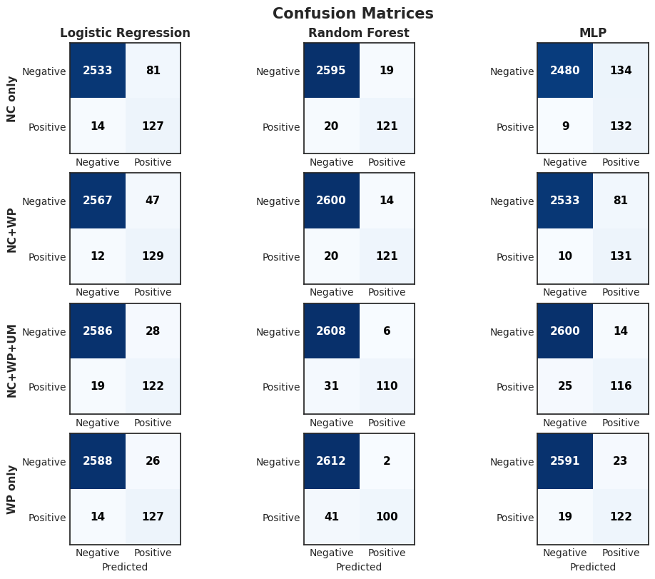

```python
lr_df = df_1024.loc[df_1024['model']=='Logistic Regression']

false_negative_id = lr_df.loc[(lr_df["y_true"]==1)&(lr_df["y_pred"]==0)]
false_positive_id = lr_df.loc[(lr_df["y_true"]==0)&(lr_df["y_pred"]==1)]

prob_score_false_positive  = false_positive_id['y_proba'].values
prob_score_false_negative  = false_negative_id['y_proba'].values
```

```python
dataset = fo.load_dataset('tiles_merged')
```

FOR THE GIF

Model: Logistic Regression trained on WPonly

LINK FALSE NEGATIVE: [FALSE NEGATIVE 1024ov224](https://github.com/emanuel-gf/Dugongs_IRISA-MARBEC-LIRMM/blob/integrate/chapter3/presentation/false_negative.gif)

LINK FALSE POSITIVE: [FALSE POSITIVE 1024OV224](https://github.com/emanuel-gf/Dugongs_IRISA-MARBEC-LIRMM/blob/integrate/chapter3/presentation/false_positive.gif)

```python
import sys
```

```python
from pathlib import Path
import sys

project_root = Path.cwd().parent

if str(project_root) not in sys.path:
    sys.path.insert(0,str(project_root))
```

```python
from src.gif_plot import create_failure_reveal_gif

info = create_failure_reveal_gif(
    filepaths= dataset[false_positive_id['sample_id'].values].values('filepath'),
    labels=prob_score_false_positive,
    output_path="false_positive.gif",
    raw_duration_s=2,
    reveal_duration_s=1,
)
```

```
GIF saved -> false_positive.gif
  Tiles: 26  Frames: 52 (2 per tile)
  Size: 10129.2 KB
  Requested durations (ms), first 4 frames: [2000, 1000, 2000, 1000]
  Actual durations read back from file, first 4 frames: [3000, 3000, 3000, 3000]
  NOTE: actual != requested -- your GIF VIEWER may still clamp or round long delays even though the file stores them correctly. Try opening the .gif directly in a browser tab (not a Slack/Discord preview or some IDE thumbnailers, which often hardcode a max delay).
  WARNING: 26 tile(s) had no bounding box found (missing/empty label file) -- reveal frame shows no box for these.
```

```python
from src.gif_plot import create_failure_reveal_gif

info = create_failure_reveal_gif(
    filepaths= dataset[false_negative_id['sample_id'].values].values('filepath'),
    labels=prob_score_false_negative,
    output_path="false_negative.gif",
    raw_duration_s=2,
    reveal_duration_s=1,
)
```

```
GIF saved -> false_negative.gif
  Tiles: 14  Frames: 28 (2 per tile)
  Size: 12857.9 KB
  Requested durations (ms), first 4 frames: [2000, 1000, 2000, 1000]
  Actual durations read back from file, first 4 frames: [2000, 1000, 2000, 1000]
```

```python
df_concat.shape
```

```
(24795, 7)
```

```python
df_concat = pd.concat([df_concat, df_1024])
df_concat.shape
```

```
(33060, 8)
```